# R tutorial for Muasya lab

## 4.5 Models!

### 4.5.1 Fitting models

```r
my_model <- lm(formula = iris$Sepal.Length ~ iris$Petal.Length)
# Or
my_model <- lm(formula = Sepal.Length ~ Petal.Length, data = iris)
```

### 4.5.2 Model inspection and interpretation

The raw model object is kind of uninformative and hard to read

```r
my_model
```

```
##
## Call:
## lm(formula = Sepal.Length ~ Petal.Length, data = iris)
##
## Coefficients:
##  (Intercept)  Petal.Length
##       4.3066        0.4089
```

So, we employ one of the most useful functions in R: `summary()`. This function can be called on multiple object types (like we used for data-frames earlier). But on model objects it is your bread-and-butter

```r
summary(my_model)
```

```
##
## Call:
## lm(formula = Sepal.Length ~ Petal.Length, data = iris)
##
## Residuals:
##      Min       1Q   Median       3Q      Max
## -1.24675 -0.29657 -0.01515  0.27676  1.00269
##
## Coefficients:
##              Estimate Std. Error t value Pr(>|t|)
## (Intercept)   4.30660    0.07839   54.94   <2e-16 ***
## Petal.Length  0.40892    0.01889   21.65   <2e-16 ***
## ---
## Signif. codes:  0 '***' 0.001 '**' 0.01 '*' 0.05 '.' 0.1 ' ' 1
##
## Residual standard error: 0.4071 on 148 degrees of freedom
## Multiple R-squared:   0.76,  Adjusted R-squared:  0.7583
## F-statistic: 468.6 on 1 and 148 DF,  p-value: < 2.2e-16
```

## 4.6 Plotting model fits

Here I employ another one of R’s strengths: community packages. The R community has made over 6000 packages, free for anyone to use. They are extra-add ons to R (I explain more below). The function `visreg()` (from the package also called visreg) takes a model object as an input and makes very nice plots of the data and fit for that model. Observe:

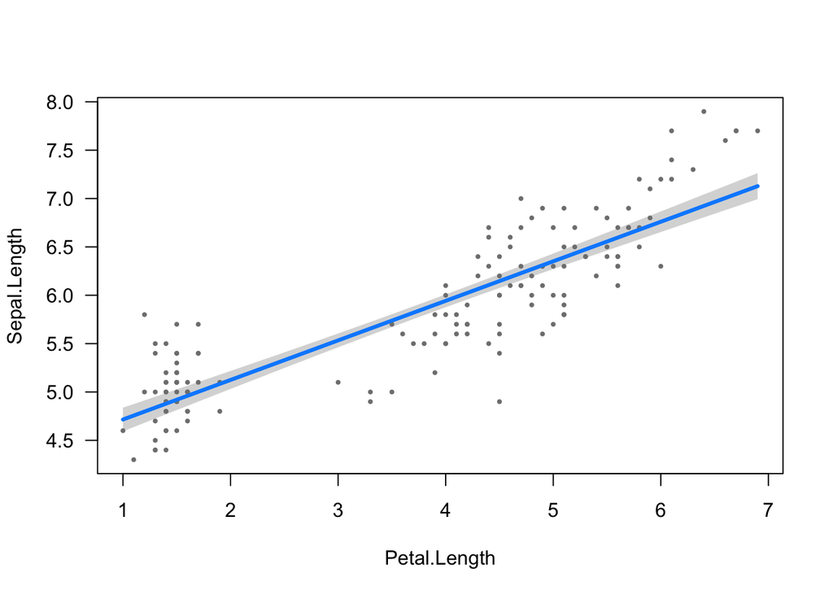

```r
# Install the package
install.packages("visreg", dependencies = TRUE)
# Load it into R's brain
library(visreg)
# Use the function "visreg" from the package "visreg"
visreg::visreg(my_model)
```

Note, the `package::function` syntax is optional. I could simply call on `visreg()` directly, as the package visreg has been loaded. But sometimes you don’t want to load a whole package into memory (for e.g. on a very computationally intensive project) so we use `::` to steal one function only from a package, use it, and put it back.

## 4.7 Saving figures and outputs

The simplest and easiest is to use the “Export” button in the plots pane in RStudio.

# 5 R packages

R packages represent bundles of functions and methods for specific computations. This is similar to the idea of modules from other languages.

R has several “base” packages, each responsible for different aspects of day-to-day work in R. For example, “base” (the name of one of the base packages itself) handles basic programming things and arithmetic, “graphics” is what R uses to make plots, and “stats” is where statistical methods are deployed from.

The reason I emphasise this is so that the idea of adding community-made, open-source packages is that someone has likely encountered the problem your having in your work, and written functions and code that solves it neatly and reliably. So take advantage of that and Google around for packages that suit your needs.

Some I use very often include

- `ggplot2` for more advanced figures
- `tidyr` and `dplyr` for data-frame manipulation and reshaping
- `raster` and `sp` for adding GIS functionality to R
- `stringr` for advanced text manipulation and character matching (very good REGEX functionality)

Some more esoteric/special-use packages include

- `dismo` for making species distribution models
- `taxize` for querying taxanomic databases with your species names, and for dealing with taxanomic hierarchies as objects in R
- `pacman` for automated R package installation
- `rmarkdown` for document preparation that relies on R input (how I made this tutorial!)